# Cointegration theory

Doynikov A

April 10, 2021

# Теория коинтеграции

Ключевые концепции теории коинтеграции впервые были сформулированы Granger(1983) и Engle (1987). В 2003 году работа Granger, Engle и были оценена Нобелевской премией по экономике.

#### Определение 1.

Пусть $x_{t}$- однородно нестационарный временной ряд. Будем говорить, что $x_{t}$ принадлежит классу $I(1)$, если его разности
$$\Delta x_{t}=x_{t}-x_{t-1}$$
является стационарным (принадлежит классу $I(0)$).

#### Определение 2

. Пусть $x_{t}$- однородно нестационарный временной ряд. Будем говорить, что $x_{t}$ принадлежит классу $I(d)$, если его разности
$$\Delta x_{t}=x_{t}-x_{t-1}$$
является рядом из класса $I(d-1)$. Пусть $y_{t}- n$-мерный временной ряд
$$y_{t}=(y_{1,t},...,y_{n,t})′$$
такой, что каждая из его компонент $y_{k,t}k=1,...,n$ взятая в отдельности представляет собой ряд из класса $I(1)$.

#### Определение 3.

Компоненты этого ряда называют коинтегрированными, если существует их нетривиальная линейная комбинация $a′y_{t}$, которая является стационарной (принадлежит классу $I(0)$).

### Пример.

Пусть $\epsilon_{t,1}$ и $\epsilon_{t,2}$ два независимых в совокупности процесса белого шума. Процесс $y_{t,2}$ такой, что
$$y_{t,2}=y_{t-1,2}+\epsilon_{t,2}$$

а процесс $y_{t,1}$
$$y_{t,1}=\gamma y_{t,2}+\epsilon_{t,1}$$

Проверим, что это процессы из $I(1)$. Действительно
$$\Delta y_{t,2}=y_{t,2}-y_{t-1,2}=y_{t-1,2}-y_{t-1,2}+\epsilon_{t,2}=\epsilon_{t,2}$$

что также является стационарным процессом. Рассмотрим вектор a вида $а=(1,-\gamma )$
$$y_{t,1}-\gamma y_{t,2} = \gamma y_{t,2}+\epsilon_{t,1}-\gamma (y_{t-1,2}+\epsilon_{t,2})$$
$$= \gamma (y_{t,2}-y_{t-1,2})+\epsilon_{t,1}-\gamma \epsilon_{t,2}$$
$$= \gamma \epsilon_{t,2}+\epsilon_{t,1}-\gamma \epsilon_{t,2}=\epsilon_{t,1}$$
Что естественно является стационарным процессом. Таким образом процессы $y_{t,1}$ и $y_{t,1}$ коинтегрированы. Естественно в определении 3 коинтегрированный вектор не является единственным. Если $а$ - вектор коитегрирования,то $ba$, где $b$ некоторая константа также является коинтегрирущим вектором. Однако, если многомерный вектор $y_{t}$ содержит более, чем две компоненты, то могут сосуществать несколько линейно независимых векторов $a_1..,a_{h}$ такие, что линейные комбинации этих векторов с $y_{t}$ будут давать стационарные процессы

#### Определение 4.

Пусть $y_{t}$ есть $n$-мерный процесс такой, что каждая из его компонет есть процесс из $I(1)$. Предположим, что существует матрица A размера $(n×h)$ такая, что: - столбцы ее линейно независимы; - $A′y_{t}$ представляют собой $h<n$ процессов из $I(0)$; тогда будем говорить, что процессы из $y_{t}$ коинтегрированы порядка $h$.

Вернемся к рассмотрению примера.Положим $e_{t,2}=\epsilon_{t,2}$, а $e_{t,1}=\gamma \epsilon_{t,2}+\epsilon_{t,1}$.Тогда правую часть уравнения для $\Delta y_{t,1}$ можно переписать следующим образом :
$$\Delta y_{t,1} = \gamma \epsilon_{t,2}+\epsilon_{t,1}-\epsilon_{t-1,1}=e_{t,1}-(e_{t-1,1}-\gamma e_{t-1,2})=
(1-B)e_{t,1}+\gamma Be_{t,2}$$

Тогда в новых обозначениях выражения для $\Delta y_{t,1}$ и $\Delta y_{t,2}$ можно записать в операторной форме
$$\begin{equation*}\left[ \begin{matrix}\Delta y_{t,1}\\\Delta y_{t,2}\end{matrix}\right]= \Psi(B)\left[ \begin{matrix}e_{t,1}\\ e_{t,2}\end{matrix}\right]\end{equation*}$$
где
$$\begin{equation*}\Psi(B)=\left[ \begin{matrix}1-B&\gamma B\\ 0&1\end{matrix}\right]\end{equation*}$$
Отсюда модель векторной авторегрессии для $\Delta y_{t,1}$ и $\Delta y_{t,2}$ ,если бы оно существовало, имело бы следующий вид
$$\Phi(B)\Delta y_{t}=e_{t}$$

где $\Phi(B)=Ψ^{-1}(B)$. Но матрица $Ψ(B)$ имеет единичный корень. Действительно, ее определитель при $B=1$ равен нулю
$$\begin{equation*}\Psi(1)=\left[ \begin{matrix}0&\gamma 1\\
0&1\end{matrix}\right]\end{equation*}$$
Следовательно оператор скользящего среднего не обратим. Отсюда не существует оператора конечного порядка типа авторегрессии для $\Delta y_{t}$. Но если мы слегка изменим определение векторной авторегресси и позволим вхождение туда не только приращений, но и значений самих $y_{t-k}$, но только с некоторой задержкой $k>0$, то стационарное представление для $\Delta y_{t}$ найти довольно легко. Действительно, возвратившись к начальному представлению $\Delta y_{t}$ через шум вида $\epsilon_{t,1}$ и $\epsilon_{t,2}$,получим
$$\begin{equation*}\left[ \begin{matrix}\Delta y_{t,1}\\\Delta y_{t,2}\end{matrix}\right]= \left[ \begin{matrix}-1&\gamma 1\\
0&0\end{matrix}\right]\left[ \begin{matrix}y_{t-1,1}\\ y_{t-1,2}\end{matrix}\right]+\left[ \begin{matrix}\gamma \epsilon_{t,2}+\epsilon_{t,1}\\ \epsilon_{t,2}\end{matrix}\right]\end{equation*}$$
Этот пример нам показал, для коинтегрированных систем авторегрессионное представление для $\Delta y_{t}$ в многомерном случае должно включать в себя члены вида $Gy_{t-1}$

### Соотношение для коррекции ошибки в коинтегрированных системах

Хотя векторная авторегрессионная модель для приращений $\Delta y_{t}$ не может быть формой представлением коинтегрированный систем, то для самих $y_{t}$ это вполне возможна, только естественно (так как компоненты $y_{t}$ из $I(1)$) это будет нестационарная модель например порядка $p$.
$$y_{t}=\alpha+\Phi_1y_{t-1}+...+\Phi_{p}y_{t-p}+\epsilon_{t}$$
или в операторной форме

$$\Phi(B)y_{t}=\alpha+\epsilon_{t}$$

где $\Phi(B)$- оператор нестационарной векторной авторегрессии вида
$$\Phi(B)=1-\Phi_1B-...-\Phi_{p}B^{p}$$

нестационарность означает, что определитель следующей матрицы равен нулю при $B=1$
$$|1-\Phi_1-...-\Phi_{p}|=0$$

Выражение для $y_{t}$ можно в данном случае эквивалентно переписать другим образом, которое и является наиболее общей формой представления коинтегрированных систем
$$y_{t}=\zeta_1\Delta y_{t-1}+...+\zeta_{p-1}\Delta y_{t-p+1}+\alpha+\rhoy_{t-1}+\epsilon_{t}$$

где
$$\rho=[\Phi_1+...+\Phi_{p}]$$
$$\zeta_{s}=-[\Phi_{s+1}+...+\Phi_{p}]$$
при
$$s=1,...,p-1$$
Вычитая $y_{t-1}$ из обеих частей получим
$$\Delta y_{t} = \zeta_1\Delta y_{t-1}+...+\zeta_{p-1}\Delta y_{t-p+1}+\alpha+\zeta_0y_{t-1}+ε_{t}$$
(1) где
$$\zeta_0 = \rho-I_{n}=-(I_{n}-Φ_1-...-Φ_{p})=-Φ(1)$$

Теперь предположим, что мы работаем с коинтегрированной системой порядка $h<n$. Т.е. существует матрица $A$ размера $(n×h)$ такая , что: - столбцы ее линейно независимы; - $A′y_{t}$ представляют собой $h<n$ процессов из $I(0)$; Тогда последнее представление для $\Delta y_{t}$ можно переписать так
$$\Delta y_{t}=\zeta_1\Delta y_{t-1}+...+\zeta_{p-1}\Delta y_{t-p+1}+\alpha-GA′y_{t-1}+ε_{t}$$
или вот так
$$\Delta y_{t}=\zeta_1\Delta y_{t-1}+...+\zeta_{p-1}\Delta y_{t-p+1}+\alpha-Gz_{t-1}+ε_{t}$$

где $z_{t-1}=A'y_{t-1}$ вектор из $h$ стационарных процессов, а матрица $G$ такая, что

$GA′=-\zeta_0$. Эти последние два выражения и называют представлением коррекции ошибки.

### Моделирование коинтегрированной системы на R

Нам необходимо задать модель вида
$$\Phi(B)y_{t}=\alpha+\epsilon_{t}$$
где $\Phi(B)$- оператор нестационарной векторной авторегрессии вида
$$\Phi(B)=1-\Phi_1B-...-\Phi_{p}B^{p}$$

```r
library(urca)
library(egcm)
library(mAr)
#Set unstable Vector AR(2) model X = A(1)*X(t-1)+A(2)*X(t-2)+E
#Set A(1) matrix(4,4)
Phi1 <-          c(0.25,0.2,    0.1,    0)
Phi1 <- rbind(Phi1,c(0,  0.2,   0.3,    0))
Phi1 <- rbind(Phi1,c(0,  0,     0.5,  0))
Phi1 <- rbind(Phi1,c(0,  0,     0,  0.5))
#Set A(2) matrix(4,4)
Phi2 <-          c(0.25,  0.1,  0.1,    0)
Phi2 <- rbind(Phi2,c(0,     0.4,    0.1,    0))
Phi2 <- rbind(Phi2,c(0,       0,  0.5,  0))
Phi2 <- rbind(Phi2,c(0,       0,    0,0.5))
Phi1+Phi2
```

```
##      [,1] [,2] [,3] [,4]
## Phi1  0.5  0.3  0.2    0
##       0.0  0.6  0.4    0
##       0.0  0.0  1.0    0
##       0.0  0.0  0.0    1
```

```r
Phi <- cbind(Phi1,Phi2)
Phi
```

```
##      [,1] [,2] [,3] [,4] [,5] [,6] [,7] [,8]
## Phi1 0.25  0.2  0.1  0.0 0.25  0.1  0.1  0.0
##      0.00  0.2  0.3  0.0 0.00  0.4  0.1  0.0
##      0.00  0.0  0.5  0.0 0.00  0.0  0.5  0.0
##      0.00  0.0  0.0  0.5 0.00  0.0  0.0  0.5
```

вектор $\alpha$ и ковариационная матрица $\Omega=cov(\epsilon_t,\epsilon_t')$

```r
w<-c(0,0,0,0)
C  <- rbind(c(4,0,0,0),c(0,1,0,0),c(0,0,1,0),c(0,0,0,4))
```

Проверим нестационарность заданной модели Для этого мы сформируем из матриц $\Phi_1,\Phi_2$ матрицу $F$ ,как в прошлой лекции и вычислим ее собственные значения.

```r
I <- diag(1,4,4)
Zero <- diag(0,4,4)
IZ <- cbind(I,Zero)
F <- rbind(Phi,IZ)
F
```

```
##      [,1] [,2] [,3] [,4] [,5] [,6] [,7] [,8]
## Phi1 0.25  0.2  0.1  0.0 0.25  0.1  0.1  0.0
##      0.00  0.2  0.3  0.0 0.00  0.4  0.1  0.0
##      0.00  0.0  0.5  0.0 0.00  0.0  0.5  0.0
##      0.00  0.0  0.0  0.5 0.00  0.0  0.0  0.5
##      1.00  0.0  0.0  0.0 0.00  0.0  0.0  0.0
##      0.00  1.0  0.0  0.0 0.00  0.0  0.0  0.0
##      0.00  0.0  1.0  0.0 0.00  0.0  0.0  0.0
##      0.00  0.0  0.0  1.0 0.00  0.0  0.0  0.0
```

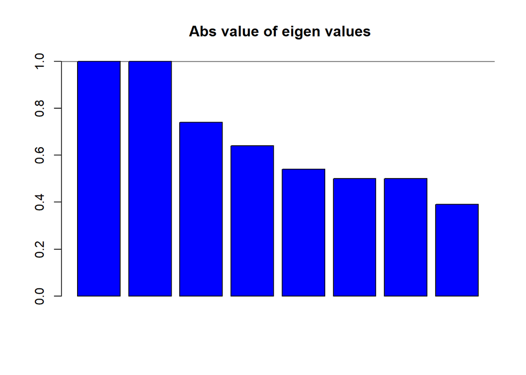

```r
eval <- eigen(F,only.values= TRUE)
modev <- Mod(eval$values)
barplot(modev,col = "blue",main = " Abs value of eigen values")
abline(h=1,col = "black")
```

Два собственных значения по модулю равны 1, следовательно ряд нестационарен.

Другой и более простой способ проверки. Убедимся, что определитель матрицы
$$|1-\Phi_1-...-\Phi_{p}|=0$$
равен нулю. Это будет означать что $B=1$ является корнем уравнения

$$1-\Phi_1B...-\Phi_{p}B^p=0$$

```r
D<- I-Phi1-Phi2
D
```

```
##      [,1] [,2] [,3] [,4]
## Phi1  0.5 -0.3 -0.2    0
##       0.0  0.4 -0.4    0
##       0.0  0.0  0.0    0
##       0.0  0.0  0.0    0
```

```r
det(D)
```

```
## [1] 0
```

Итак условия нестационарности выполнены приступаем к моделированию

```r
data<-  mAr.sim(w,Phi,C,N=300)
```

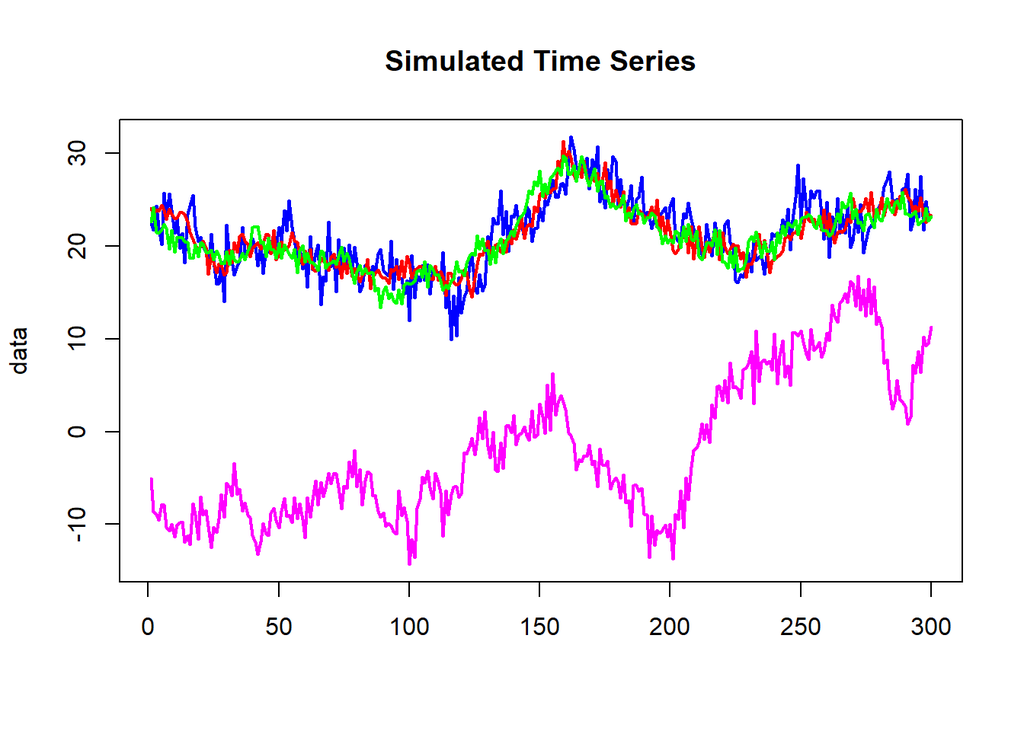

```r
data<- as.matrix(data)
matplot(data,main="Simulated Time Series",col = c("blue","red","green","magenta"),type = "l",lty=1,lwd = 2)
```

### Оценка модели коинтеграции

Сначала идет 2-х шаговый МНК

1.1 Оценки параметров множественной регрессионной модели связи $\Delta y_{t}$ с $\Delta y_{t-1},\Delta y_{t-2},...\Delta y_{t-p+1}$

$\Delta y_{t}=\pi+\Pi_1\Delta y_{t-1}...+\Pi_{p-1}\Delta y_{t-p+1}+u_{t}$

1.2 Оценки параметров множественной регрессионной модели связи  
$y_{t}$ с $\Delta y_{t-1},\Delta y_{t-2},...\Delta y_{t-p+1}$

$y_{t}=\theta+\Lambda_1\Delta y_{t-1}...+\Lambda_{p-1}\Delta y_{t-p+1}+v_{t}$

2.1 Здесь вычисляется ковариационные матрицы остатков

$\Sigma_{vv}={cov(v_{i},v_{j});i,j=1,...,n}$

$\Sigma_{u u }={cov(u_{i},u_{j});i,j=1,...,n}$

$\Sigma_{u v}={cov(u_{i},v_{j});i,j=1,...,n}$

$\Sigma_{vu}=Σ_{u v}′$

И затем находят собственные значения $\lambda_1₁,...,\lambda_{n}$ матрицы

$\Sigma = \Sigma_{vv}^{-1}\Sigma_{u v}\Sigma_{u u}^{-1}\Sigma_{u v}$

которые упорядочивают по убыванию $\lambda_1>...>\lambda_{n}$. Полученные собственные значения впоследствии будут использоваться для проверки гипотез о порядке коинтеграции.

3.Пусть $a_1,...,a_{h}$ первые $h$ собственных векторов, отвечающие соответсвующим собственным значениям$\lambda_1>...>\lambda_{n}$,нормализованные так, чтобы

$a_{i}′\Sigma_{vv}a_{j}=1$

Составим из них матрицу $A=[a_1₁,...,a_{h}]$

Тогда оценкой максимального правдоподобия для $\zeta_0$ будет

$\zeta_0=\Sigma_{uv}AA′$

оценками максимального правдоподобия для $\zeta_{i} i=1,...,p-1$ будут

$\zeta_{i}=\Pi_{i}-\zeta_0\Lambda_{i}$

а оценкой максимального правдоподобия для $\alpha$ будет

$\alpha=\pi-\zeta_0\theta$

Итак мы нашли значения оценок модели коинтеграции

## Проверка гипотез о коинтеграции

В качестве основной рассмотрим гипотезу о том, что существует в точности $h$ коинтеграционных соотношений. Это эквивалентно тому, что $\zeta_0$ может быть записана в форме

$\zeta_0=-BA′$

где матрица $B$- размера $(n×h)$, a $A′(n×h)$ . При этом предположении максимальная величина, которую может достичь логарифм функции правдоподобия задается выражением

$$L^{∗}=-((Tn)/2)log2π-((Tn)/2)-(T/2)log|\Sigma_{uu}|-(T/2)\Sigma_{i=1}^{h}log(1-λ_{i})$$

Теперь рассмотрим альтернативную гипотезу, что существует $n$ коинтеграционных соотношений, где $n$- размерность вектора $y_{t}$. Это означает, что любая линейная комбинация $y_{t}$ является стационарной. Значения логарифма функции правдоподобия в данном предположении будет
$$L_{А}^{∗}=-((Tn)/2)log2π-((Tn)/2)-(T/2)log|Σ_{uu}|-(T/2)∑_{i=1}ⁿlog(1-λ_{i})$$
Тест отношения правдоподобия для проверки основной гипотезы, против данной альтернативы
$$L_{А}^{∗}-L₀^{∗}=(T/2)∑_{i=h+1}ⁿlog(1-λ_{i})$$

Распределение $λ_{i}$ , а следовательно и $L^{∗}$ имеет сложный вид, поэтому значения статистик для проверки гитотез о порядке коинтеграции затабулированы в таблицах. Таблицы довольно обширные зависят от уровня значимости, порядка коинтеграции, длины выборки. Таблицы получены С.Йехансоном методом статистического моделирования. с именем Йехансона и связано соответствующего названия метода ca.jo в R из библиотеки urca.

Проведем оценку параметров и проверку статистических гипотез в R для смоделированных ранее 4 рядов.

```r
vecm <- ca.jo(data, ecdet = "none",type="eigen",K=3,spec="longrun")
summary(vecm)
```

```
##
## ######################
## # Johansen-Procedure #
## ######################
##
## Test type: maximal eigenvalue statistic (lambda max) , with linear trend
##
## Eigenvalues (lambda):
## [1] 0.19911379 0.16468813 0.03115438 0.01382548
##
## Values of teststatistic and critical values of test:
##
##           test 10pct  5pct  1pct
## r <= 3 |  4.13  6.50  8.18 11.65
## r <= 2 |  9.40 12.91 14.90 19.19
## r <= 1 | 53.45 18.90 21.07 25.75
## r = 0  | 65.94 24.78 27.14 32.14
##
## Eigenvectors, normalised to first column:
## (These are the cointegration relations)
##
##             X1.l3       X2.l3      X3.l3     X4.l3
## X1.l3  1.00000000   1.0000000   1.000000 1.0000000
## X2.l3 -0.81091148  20.6794409   6.300679 1.3990537
## X3.l3 -0.23161872 -20.4864713 -27.429151 0.6588813
## X4.l3 -0.01346887  -0.2486591   9.959048 1.0067616
##
## Weights W:
## (This is the loading matrix)
##
##            X1.l3         X2.l3         X3.l3         X4.l3
## X1.d -0.54910686 -0.0054393377  7.230383e-04  0.0014354116
## X2.d  0.04593621 -0.0156065251 -1.197803e-04  0.0028618468
## X3.d  0.05024930 -0.0004807018  2.313507e-03 -0.0008061496
## X4.d  0.01666998 -0.0102464507 -7.450431e-05 -0.0154349162
```

```r
vecm@cval
```

```
##          10pct  5pct  1pct
## r <= 3 |  6.50  8.18 11.65
## r <= 2 | 12.91 14.90 19.19
## r <= 1 | 18.90 21.07 25.75
## r = 0  | 24.78 27.14 32.14
```

```r
vecm@teststat
```

```
## [1]  4.134816  9.400048 53.445187 65.944812
```

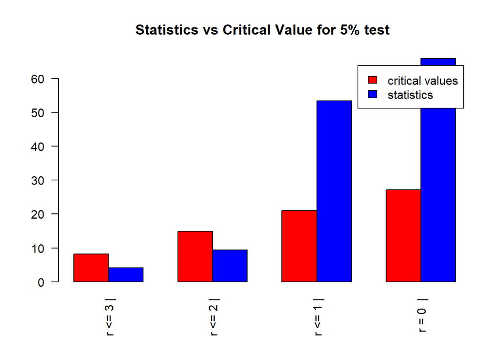

```r
outmat <-rbind(vecm@cval[,2],vecm@teststat)
legends <- c("critical values","statistics")
barplot(outmat, main="Statistics vs Critical Value for 5% test ",legend.text = legends,beside = TRUE, col=c("red","blue"), las=2)
```

Проверка гипотезы о порядке коинтеграции показывает, что порядок коинтеграции в нашей смоделированной 4-мерной системе векторов $y_t, h\le2$.

Очень полезен и визуальный спобоб проверки гипотезы о порядке $h$ коинтеграции, основанный на определении. $a$- коинтегрирующий вектор, если линейная комбинация $a′y_{t}$,должна быть стационарной (принадлежать классу $I(0)$). Вот и посмотрим

Линейная кобинация с первым вектором

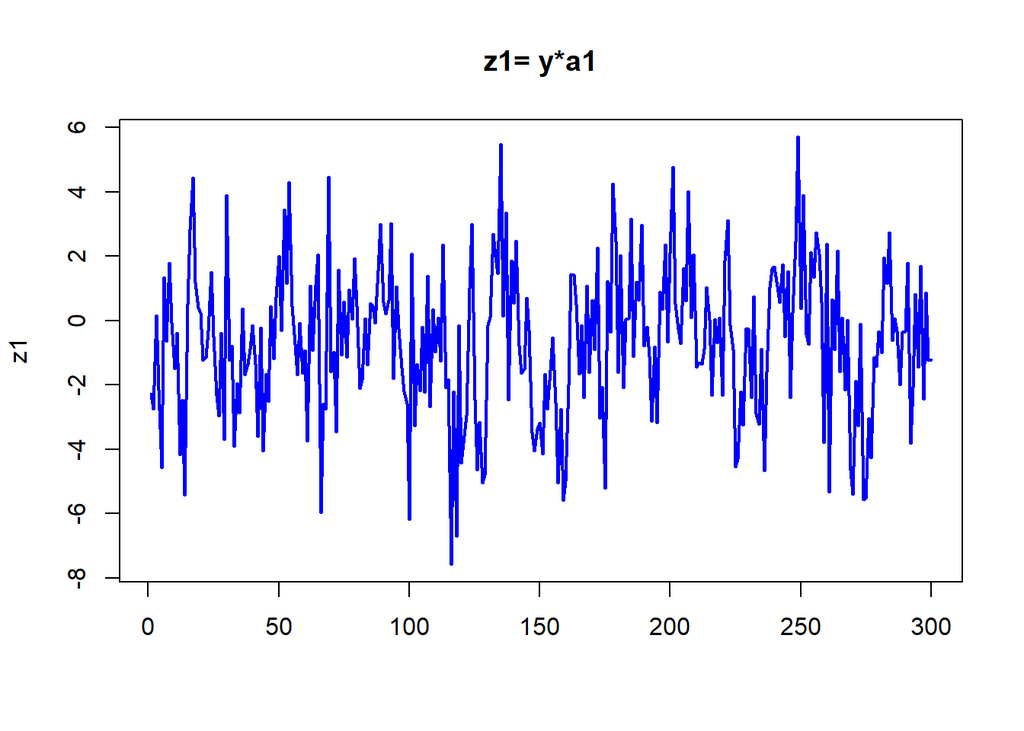

```r
  z1 <- data%*%vecm@V[,1]
  matplot(z1,type ="l",col = "blue",lwd = 2,main ='z1= y*a1')
```

на вид стационарна.Линейная кобинация со вторым вектором

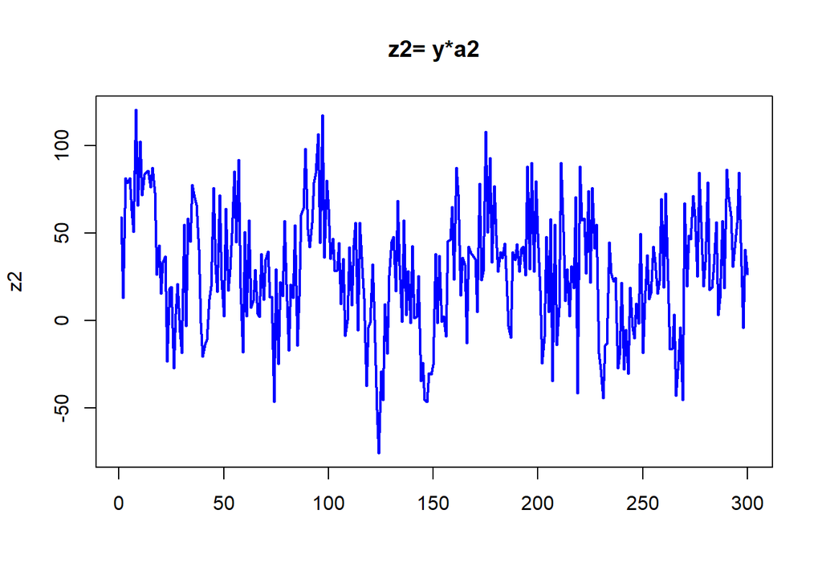

```r
  z2 <- data%*%vecm@V[,2]
  matplot(z2,type ="l",col = "blue",lwd = 2,main ='z2= y*a2')
```

также стационарна на вид.Линейная кобинация с третьим вектором

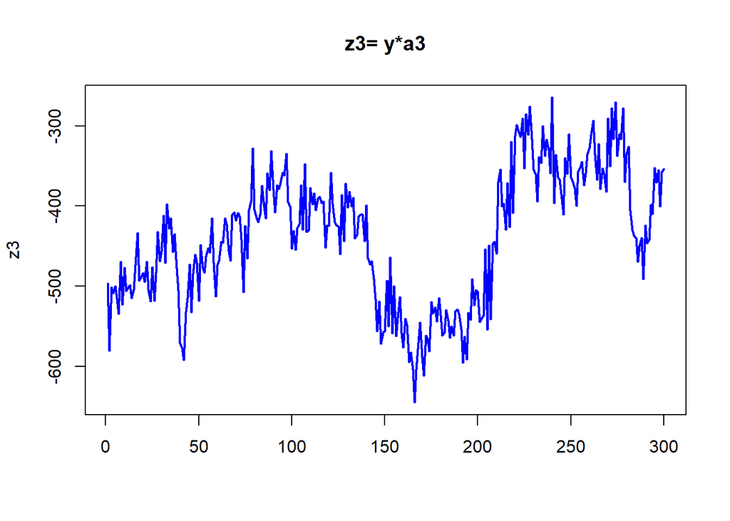

```r
  z3 <- data%*%vecm@V[,3]
  matplot(z3,type ="l",col = "blue",lwd = 2,main ='z3= y*a3')
```

Уже содержит явный тренд и не следовательно является стационарной. Таким образом наша гипотеза о порядке коинтеграции $h=2$ не отвергается и в результате визуального теста.

Посмотрим на результатах оценки модели к реальным данным- фьючерсам на индексы РТС и Ruble/USD,Brent.

```r
library(urca)
rtsData <- read.csv("c:/Shurd/ALection/RublerRTSBrent.csv")
rts <- rtsData[,2:4]
dim(rts)
```

```
## [1] 382   3
```

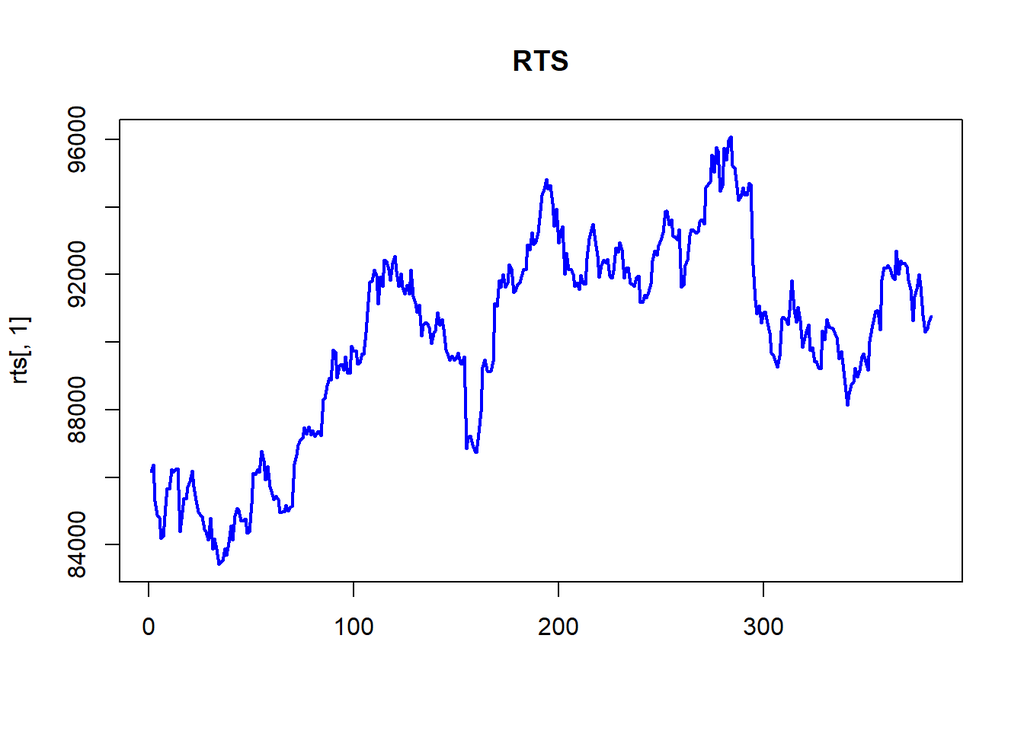

```r
matplot(rts[,1],lwd=2,main="RTS",type="l",col="blue")
```

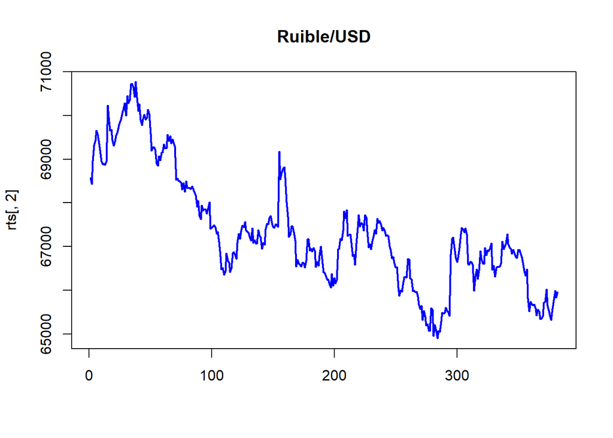

```r
matplot(rts[,2],lwd=2,main="Ruible/USD",type="l",col="blue")
```

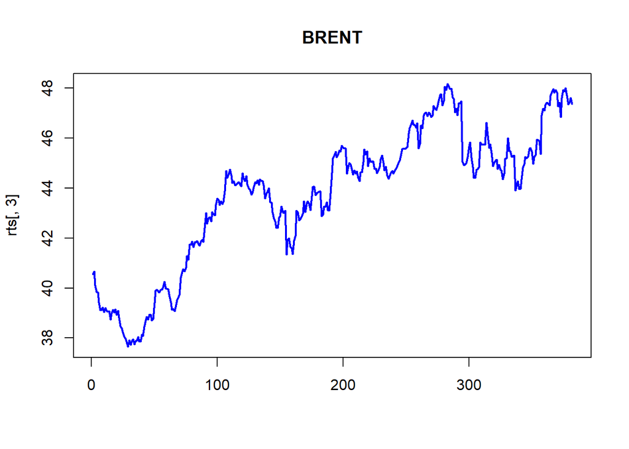

```r
matplot(rts[,3],lwd=2,main="BRENT",type="l",col="blue")
```

```r
vecm <- ca.jo(rts, ecdet = "none",type="eigen",K=3,spec="longrun")
summary(vecm)
```

```
##
## ######################
## # Johansen-Procedure #
## ######################
##
## Test type: maximal eigenvalue statistic (lambda max) , with linear trend
##
## Eigenvalues (lambda):
## [1] 0.068547244 0.012498484 0.003111798
##
## Values of teststatistic and critical values of test:
##
##           test 10pct  5pct  1pct
## r <= 2 |  1.18  6.50  8.18 11.65
## r <= 1 |  4.77 12.91 14.90 19.19
## r = 0  | 26.91 18.90 21.07 25.75
##
## Eigenvectors, normalised to first column:
## (These are the cointegration relations)
##
##              RTS.l3      Si.l3   Brent.l3
## RTS.l3        1.000   1.000000    1.00000
## Si.l3      1184.002   1.265989    1.79123
## Brent.l3 567023.664 -23.448800 -627.22827
##
## Weights W:
## (This is the loading matrix)
##
##                RTS.l3         Si.l3      Brent.l3
## RTS.d    3.244002e-05 -3.136059e-02  7.518170e-03
## Si.d    -8.377620e-05  1.027574e-02 -5.194228e-03
## Brent.d -2.410370e-08 -8.347087e-06  1.026592e-05
```

```r
vecm@cval
```

```
##          10pct  5pct  1pct
## r <= 2 |  6.50  8.18 11.65
## r <= 1 | 12.91 14.90 19.19
## r = 0  | 18.90 21.07 25.75
```

```r
vecm@teststat
```

```
## [1]  1.181210  4.766777 26.912717
```

[figure not shown]

```r
outmat <-rbind(vecm@cval[,3],vecm@teststat)
legends <- c("critical values","statistics")
barplot(outmat, main="Statistics vs Critical Value for 5% test ",legend.text = legends,beside = TRUE, col=c("red","blue"), las=2)
```

Из последней картинки следует, что порядок коинтеграции равен 1.

Собственные значения

$\lambda_1,\lambda_2,\lambda_3$

```r
vecm@lambda
```

```
## [1] 0.068547244 0.012498484 0.003111798
```

Коинтегрирующие вектора $a =(a_1,... ,a_3)$ .

```r
a<- vecm@V[,1:3]
a
```

```
##              RTS.l3      Si.l3   Brent.l3
## RTS.l3        1.000   1.000000    1.00000
## Si.l3      1184.002   1.265989    1.79123
## Brent.l3 567023.664 -23.448800 -627.22827
```

Оценки константы

```r
vecm@GAMMA[,1]
```

```
##       RTS.d        Si.d     Brent.d
##  710.148369 7916.698888    2.114813
```

Оценки матрицы $\zeta_1$

```r
vecm@GAMMA[,2:4]
```

```
##               RTS.dl1        Si.dl1    Brent.dl1
## RTS.d   -1.570941e-01 -0.2794702809 -15.64334974
## Si.d     2.942576e-03 -0.0855494017 -15.75743173
## Brent.d -5.551113e-05 -0.0001457525  -0.06175868
```

```r
vecm@GAMMA[,5:7]
```

```
##               RTS.dl2        Si.dl2    Brent.dl2
## RTS.d   -0.0918991177 -0.2488321328 -16.10989723
## Si.d     0.0740497855  0.0944815226   8.56665672
## Brent.d -0.0001315527 -0.0003132918  -0.03885834
```

Напоследок приведу пример, где показывается, что, несмотря на внешнее сходство, регрессия и коинтеграция это разные вещи.

Известен следующий факт: Пусть имеется двухмерный процесс $X_t=(X_{t,1},X_{t,2}),t = 1,...,N$ Оценка регрессии вида
$$X_{t,1}= aX_{t,2}+\epsilon_t$$
одного вектора относительного другого дает нам вектор $(1,-\tilde a)$, который является состоятельной оценкой вектора коинтеграции

Пусть процесс $X_t=(X_{t,1},X_{t,2}),t = 1,...,N$ есть процесс векторной авторегрессии второго порядка
$$X_t=\Pi_1X_{t-1}+\Pi_2X_{t-2}+\mu+\epsilon_t$$
где матрица $\Pi_1$
$$\Pi_{1,1}^{(1)} = 0.924,\Pi_{2,1}^{(1)} = -0.134$$
$$\Pi_{2,1}^{(1)} = 0.001,\Pi_{2,2}^{(1)} = 0.986$$
, матрица $\Pi_2$
$$\Pi_{1,1}^{(2)}= 0.047,\Pi_{2,1}^{(2)}= 0.403$$
$$\Pi_{2,1}^{(2)}= 0.002,\Pi_{2,2}^{(2)}= -0.044$$

вектор $\mu$
$$\mu=(0.073,-0.004)$$
,
$$\epsilon_t=(\epsilon_{t,1},\epsilon_{t,2})$$
$$E[\epsilon_{t,i}]= 0,D[\epsilon_{t,i}] = 20$$
,
$$cov(\epsilon_{t,1},\epsilon_{t,2}= 0)$$

В следующем shiny application попробуем определить оценку $\tilde a$ компоненту вектора $a=(1,-\tilde a)$ вручную и сравнить с оценкой через регрессиию и через коинтеграцию. https://shiny.ilykei.com/ANDoynikov/cointegration/

#Литература#

- Hamilton J.D. (1994): Time Series Analysis. Princeton University Press.
- Johansen, S. (1988), Statistical Analysis of Cointegration Vectors, Journal of Economic Dynamics and Control, 12, 231–254.
- Johansen, S. and Juselius, K. (1990), Maximum Likelihood Estimation and Inference on Cointegration – with Applications to the Demand for Money, Oxford Bulletin of Economics and Statistics, 52, 2, 169–210.
- Johansen, S. (1991), Estimation and Hypothesis Testing of Cointegration Vectors in Gaussian Vector Autoregressive Models, Econometrica, Vol. 59, No. 6, 1551–1580.